# Puppy Raiser Questionnaire vs Outcome (Success, Fail)

Marinara Marcato

# 1 Introduction

In order to objectively evaluate trainee guide dogs personality, their puppy raisers filled out the standardised questionnaire Canine Behavioural Assessement & Research Questionnaire (C-BARQ) around the time they were due to start formal training. This document shows the data analysis carried out to investigate the association between ratings given by the puppy raisers and the dog’s training outcome. Statistical methods will be used to test the hypothesis that there is a relationship between personality ratings and training outcome (Success, Fail). # Data Exploration

Importing data and converting variables to adequate data types.

## 1.1 Demographics

The number of dogs in the Puppy Raiser Questionnaire dataset. Selection criteria: dogs who successed training (assistance and guide dogs) and dogs withdrawn for behavioural reasons.

```
## Number of dogs: 63
```

```
## Training Outcome:
```

```
##
##    Fail Success
##      11      52
```

Analysing categorical demographic data: Sex, Breed. There was only one German Shepherd and Golden Doodle dogs in the sample, their breeds were relabeled as “Other” for the data analysis.

```
##
##  F  M
## 30 33
```

```
## [1] "Original classes"
```

```
##
## GRxPoodle        GS        LR       LRx     LRxGR
##         1         1        25         9        27
```

```
## [1] "Processed classes"
```

```
##
## Other    LR LRxGR
##     2    25    36
```

Analysing age at arrival to the training centre and age at assessment when the questionnaire was completed:

```
## Age at Arrival: Mean 15.27 Standard Deviation 2.75
```

```
## Age at Assessment: Mean 16.13 Standard Deviation 3.4
```

Calculate statistics of duration of training for the dogs that were withdrawn from training.

```
## [1] "Duration of Training in weeks"
```

```
##     Duration
##  Min.   : 1.143
##  1st Qu.: 9.786
##  Median :13.000
##  Mean   :13.935
##  3rd Qu.:15.214
##  Max.   :31.143
```

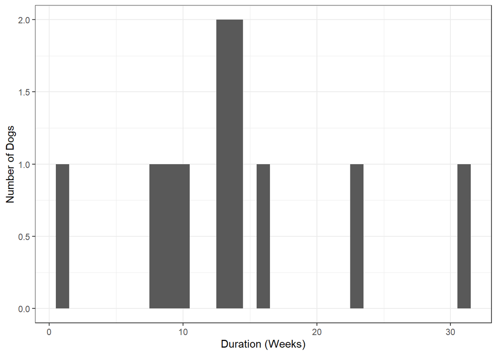

## 1.2 Descriptive Statistics

The C-BARQ contains 100 items which were scored by the Puppy Raisers in a scale from ‘Never’, ‘Seldom’, ‘Sometimes’, ‘Usually’, ‘Always’ and encoded in a scale from 0 to 4. Out of the 100 items, 78 items are used to calculate 14 factors and the remaining 22 items are myscellaneous. The questionnaire data are kept as numeric, rather than being converted to factors, so the information about the ordering is kept. The descriptive statistics of the questionnaire data shown below are calculated and saved as a csv.  
Missing data is also analysed.

```
## [1] "Items"
```

```
##   [1] "X1.When.off.the.leash.returns.immediately.when.called"
##   [2] "X2.Obeys.the.sit.command.immediately"
##   [3] "X3.Obeys.the.stay.command.immediately"
##   [4] "X4.Seems.to.attendlisten.closely.to.everything.you.say.or.do"
##   [5] "X5.Slow.to.respond.to.correction.or.punishment.thickskinned"
##   [6] "X6.Slow.to.learn.new.tricks.or.tasks"
##   [7] "X7.Easily.distracted.by.interesting.sights.sounds.or.smells"
##   [8] "X8.Will.fetch.or.attempt.to.fetch.sticks.balls.or.objects"
##   [9] "X9.When.verbally.corrected.or.punished.scolded.shouted.at.etc.by.you.or.a.household.member"
##  [10] "X10.When.approached.directly.by.an.unfamiliar.adult.while.being.walkedexercised.on.a.leash"
##  [11] "X11.When.approached.directly.by.an.unfamiliar.child.while.being.walkedexercised.on.a.leash"
##  [12] "X12.Toward.unfamiliar.persons.approaching.the.dog.while.she.is.in.your.car.at.the.gas.station.for.example"
##  [13] "X13.When.toys.bones.or.other.objects.are.taken.away.by.a.household.member"
##  [14] "X14.When.bathed.or.groomed.by.a.household.member"
##  [15] "X15.When.an.unfamiliar.person.approaches.you.or.another.member.of.your.family.at.home"
```

[output cut: 85 more lines]

```
## [1] "Factors, Demographic and Outcome"
```

```
## 'data.frame':    63 obs. of  17 variables:
##  $ F_01.Stranger.directed.aggression: num  0.1 0 0.2 0 0 0 0 0.1 0.2 0 ...
##  $ F_02.Owner.directed.aggression   : num  0 0 0 0 0 0 0 0 0 0 ...
##  $ F_03.Dog.directed.aggression     : num  0 0 0 0 1 0 0 0 0 0 ...
##  $ F_04.Dog.directed.fear           : num  0.5 0 0.25 0.25 0 ...
##  $ F_05.Dog.rivalry                 : num  NA 0 0.25 0 NA 0 0 0 0.5 0 ...
##  $ F_06.Trainability                : num  3 3 3.12 3.62 2.62 ...
##  $ F_07.Chasing                     : num  1.25 0.667 1.75 2.25 1.333 ...
##  $ F_08.Stranger.directed.fear      : num  0 0 0.25 0 0 0 0 0 0 0 ...
##  $ F_09.Nonsocial.fear              : num  0 0 0.833 0.333 0 ...
##  $ F_10.Separation.related.problems : num  0.125 0.875 0.75 0 0.625 0 0 0.75 1 0.375 ...
##  $ F_11.Touch.sensitivity           : num  0.25 0 1.25 0 0 ...
##  $ F_12.Excitability                : num  2 0.6 2.167 0.833 0.833 ...
##  $ F_13.Attachment.attention.seeking: num  1.83 2 2.83 0.5 1.6 ...
##  $ F_14.Energy                      : num  3 2 2 0 1.5 0 2 4 1 1.5 ...
##  $ Sex                              : Factor w/ 2 levels "F","M": 1 2 2 2 2 2 2 1 2 1 ...
##  $ Breed                            : Factor w/ 3 levels "Other","LR","LRxGR": 3 3 2 3 3 3 3 3 3 3 ...
##  $ Outcome                          : Factor w/ 2 levels "Success","Fail": 1 1 1 1 1 1 1 2 1 1 ...
```

```
## [1] "Features sorted by number of missing rows"
```

```
##                                                                                                                                    Missing
## X49.When.having.nails.clipped.by.a.household.member                                                                                     28
## X76.Chases.or.would.chase.squirrels.rabbits.and.other.small.animals.given.the.opportunity                                               18
## X34.When.approached.while.eating.by.another.familiar.household.dog.NA.if.no.other.dogs                                                  12
## X33.When.approached.at.a.favorite.restingsleeping.place.by.another.familiar.household.dog.NA.if.no.other.dogs                           11
## F_05.Dog.rivalry                                                                                                                        11
## X32.Towards.another.familiar.dog.in.your.household.NA.if.no.other.dogs                                                                  10
## X35.When.approached.while.playing.withchewing.a.favorite.toy.bone.object.etc.by.another.familiar.household.dog.NA.if.no.other.dogs      10
## X74.Chases.or.would.chase.cats.given.the.opportunity                                                                                     7
## X93.Stares.intently.at.nothing.visible                                                                                                   7
## X100.Displays.other.bizarre.strange.or.repetitive.behaviors                                                                              7
## X5.Slow.to.respond.to.correction.or.punishment.thickskinned                                                                              6
## X9.When.verbally.corrected.or.punished.scolded.shouted.at.etc.by.you.or.a.household.member                                               6
## X77.Escapes.or.would.escape.from.home.or.yard.given.the.chance                                                                           6
## X96.Chasesfollows.shadows.light.spots.etc                                                                                                5
## X52.When.unfamiliar.dogs.visit.your.home                                                                                                 4
```

## 1.3 Univariate Logistic Regression

Logistic Regression one-way analysis of variance test was used to investigate whether there was a statistically significant difference between the behaviours reported by Puppy Raisers and the Training Outcome of the dogs. C-BARQ Correlation with Training Outcome.

```
## $Breed
##
## Call:
## glm(formula = Outcome ~ x, family = binomial(link = logit), data = data,
##     na.action = na.exclude)
##
## Deviance Residuals:
##     Min       1Q   Median       3Q      Max
## -1.1774  -0.7409  -0.4854  -0.4854   2.0963
##
## Coefficients:
##               Estimate Std. Error z value Pr(>|z|)
## (Intercept)  4.690e-15  1.414e+00   0.000    1.000
## xLR         -1.153e+00  1.490e+00  -0.774    0.439
## xLRxGR      -2.079e+00  1.510e+00  -1.377    0.169
##
## (Dispersion parameter for binomial family taken to be 1)
##
##     Null deviance: 58.352  on 62  degrees of freedom
## Residual deviance: 55.442  on 60  degrees of freedom
## AIC: 61.442
##
## Number of Fisher Scoring iterations: 4
```

```
## Difference between Other and LR:      0.4390785   -> not significant
```

```
## Difference between Other and LRxGR:   0.1685832   -> not significant
```

```
## [1] "Columns 9,10,13,17,30,37 are CONSTANT, that's why they p_values don't make sense"
```

```
## [1] -4.443853 -4.680547 -4.680547 -4.680547 -4.680547 -4.614145
```

Analysing p-values.

```
## [1] "Number of features considering each level of significance using Logistic Regression p-value test"
```

```
## significant_0.05  significant_0.1  significant_0.2
##               29               43               56
```

Analysing deviance of full model compared to the null model. Reduction in deviance must be significant (chi-squared test) for the model to be considered a good fit.

```
## Number of features whose univariate models resulted in a significant difference in deviance:  65
```

Data selection based on the univariate logistic regression p-value and deviance analysis. This reduced feature set contains all factors and only items that were NOT included in the calculation of ANY factor with p<0.05 (i.e. Items 1,27 an 75 and some myscellaneous items 77-90, 93-100).

```
## [1] "All features with level of significance < 0.05 using Univariate Logistic Regression p-value test"
```

```
## Full Feature Set with p<0.05  63 30
```

```
##  [1] "X1.When.off.the.leash.returns.immediately.when.called"
##  [2] "X26.Toward.unfamiliar.dogs.visiting.your.home"
##  [3] "X27.Toward.cats.squirrels.or.other.small.animals.entering.your.yard"
##  [4] "X29.When.barked.growled.or.lunged.at.by.another.unfamiliar.dog"
##  [5] "X38.In.response.to.sudden.or.loud.noises.eg.vacuum.cleaner.car.backfire.road.drills.objects.being.dropped.etc"
##  [6] "X45.When.approached.directly.by.an.unfamiliar.dog.of.the.same.or.larger.size"
##  [7] "X53.When.barked.growled.or.lunged.at.by.an.unfamiliar.dog"
##  [8] "X54.Shaking.shivering.or.trembling"
##  [9] "X56.Restlessnessagitationpacing"
## [10] "X57.Whining"
## [11] "X61.Barking"
## [12] "X62.When.you.or.other.members.of.the.household.come.home.after.a.brief.absence"
## [13] "X63.When.playing.with.you.or.other.members.of.your.household"
## [14] "X64.When.doorbell.rings"
## [15] "X65.Just.before.being.taken.for.a.walk"
## [16] "X66.Just.before.being.taken.on.a.car.trip"
## [17] "X75.Chases.or.would.chase.birds.given.the.opportunity"
## [18] "X77.Escapes.or.would.escape.from.home.or.yard.given.the.chance"
## [19] "X82.Begs.persistently.for.food.when.people.are.eating"
## [20] "X85.Pulls.excessively.hard.when.on.the.leash"
## [21] "X90.Hyperactive.restless.has.trouble.settling.down"
## [22] "X93.Stares.intently.at.nothing.visible"
## [23] "X99.Licks.people.or.objects.excessively"
## [24] "F_01.Stranger.directed.aggression"
## [25] "F_03.Dog.directed.aggression"
## [26] "F_04.Dog.directed.fear"
## [27] "F_09.Nonsocial.fear"
## [28] "F_10.Separation.related.problems"
## [29] "F_12.Excitability"
## [30] "Outcome"
```

```
## Reduced Feature Set with p<0.05   63 16
```

```
##  [1] "X1.When.off.the.leash.returns.immediately.when.called"
##  [2] "X27.Toward.cats.squirrels.or.other.small.animals.entering.your.yard"
##  [3] "X75.Chases.or.would.chase.birds.given.the.opportunity"
##  [4] "X77.Escapes.or.would.escape.from.home.or.yard.given.the.chance"
##  [5] "X82.Begs.persistently.for.food.when.people.are.eating"
##  [6] "X85.Pulls.excessively.hard.when.on.the.leash"
##  [7] "X90.Hyperactive.restless.has.trouble.settling.down"
##  [8] "X93.Stares.intently.at.nothing.visible"
##  [9] "X99.Licks.people.or.objects.excessively"
## [10] "F_01.Stranger.directed.aggression"
## [11] "F_03.Dog.directed.aggression"
## [12] "F_04.Dog.directed.fear"
## [13] "F_09.Nonsocial.fear"
## [14] "F_10.Separation.related.problems"
## [15] "F_12.Excitability"
## [16] "Outcome"
```

## 1.4 Missing Data

PRQ, missing values per column and per row. Very few data are missing considering the original items selected.

```
##               X1.When.off.the.leash.returns.immediately.when.called
##                                                                   0
## X27.Toward.cats.squirrels.or.other.small.animals.entering.your.yard
##                                                                   2
##               X75.Chases.or.would.chase.birds.given.the.opportunity
##                                                                   1
##      X77.Escapes.or.would.escape.from.home.or.yard.given.the.chance
##                                                                   6
##               X82.Begs.persistently.for.food.when.people.are.eating
##                                                                   1
##                        X85.Pulls.excessively.hard.when.on.the.leash
##                                                                   1
##                  X90.Hyperactive.restless.has.trouble.settling.down
##                                                                   1
##                              X93.Stares.intently.at.nothing.visible
##                                                                   7
##                             X99.Licks.people.or.objects.excessively
##                                                                   3
##                                   F_01.Stranger.directed.aggression
##                                                                   0
##                                        F_03.Dog.directed.aggression
##                                                                   0
##                                              F_04.Dog.directed.fear
##                                                                   0
##                                                 F_09.Nonsocial.fear
##                                                                   0
##                                    F_10.Separation.related.problems
##                                                                   1
##                                                   F_12.Excitability
##                                                                   0
##                                                             Outcome
##                                                                   0
```

```
## row_nas
##  0  1  2  7
## 49 10  3  1
```

## 1.5 Visualization

Plotting the items and factors that will be used for modelling.

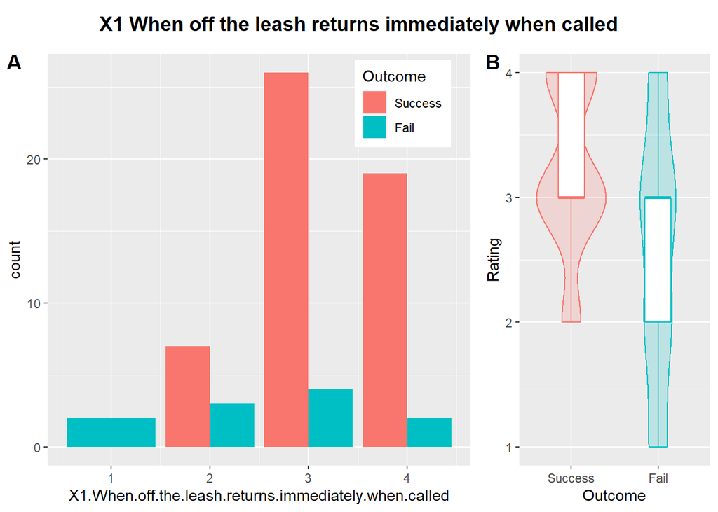

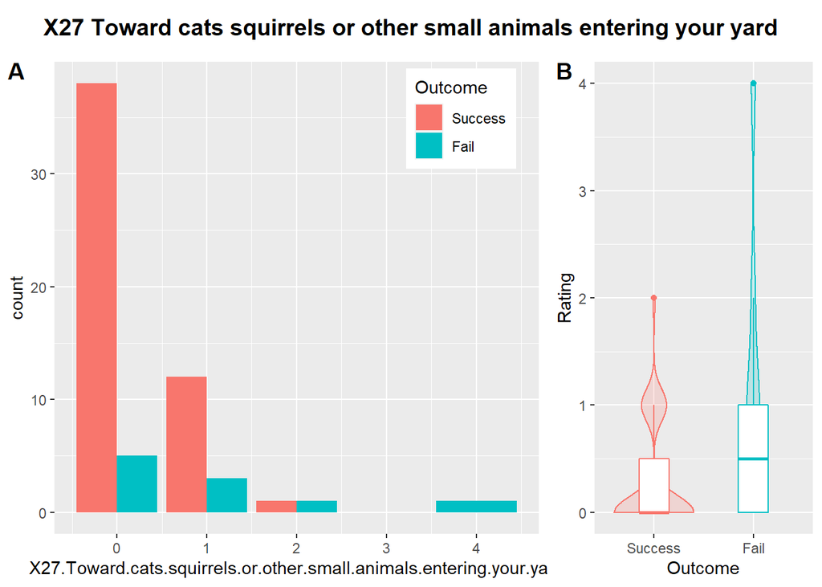

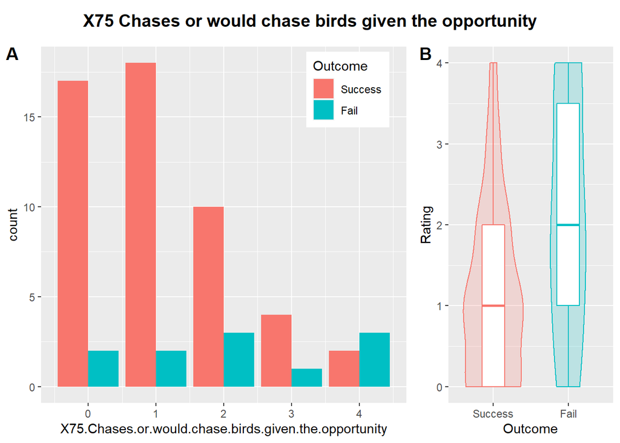

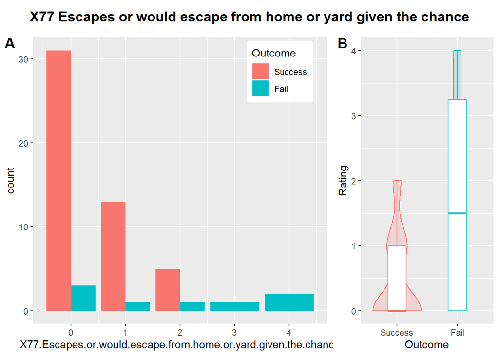

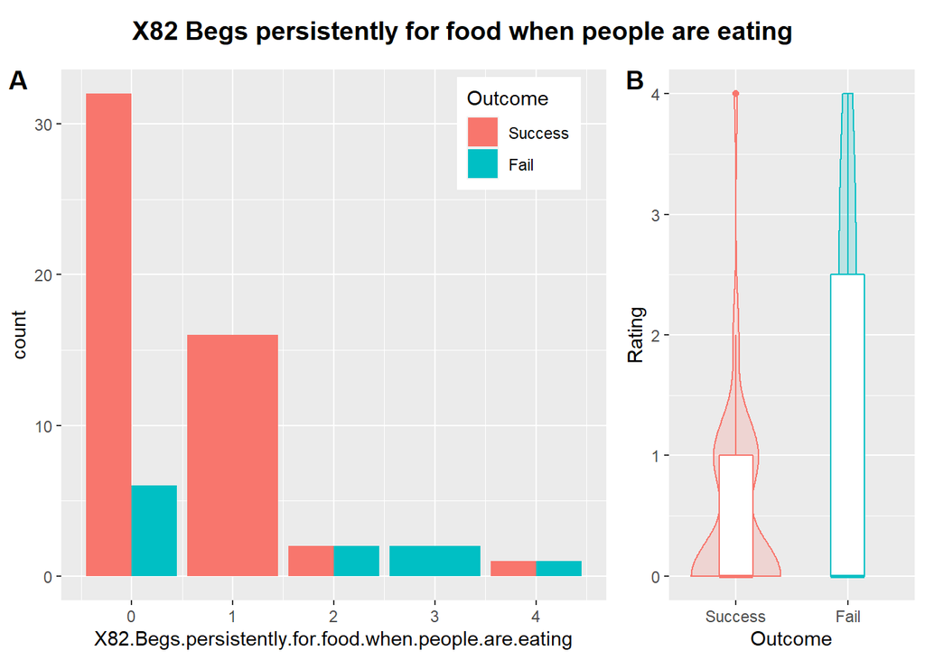

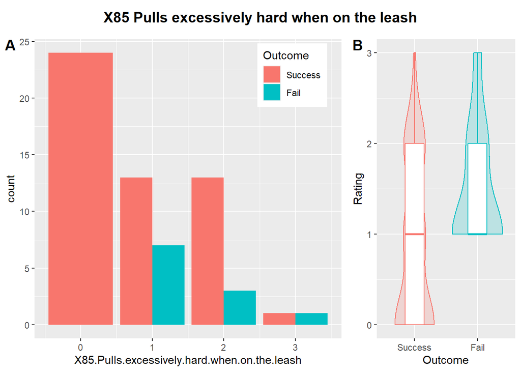

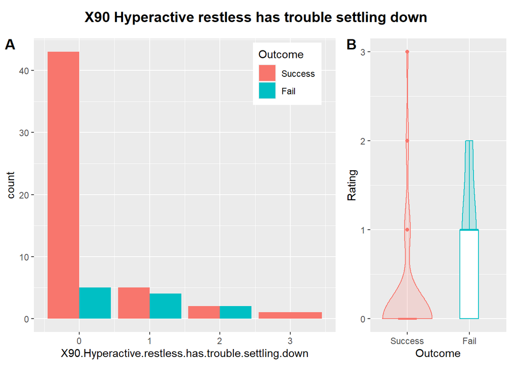

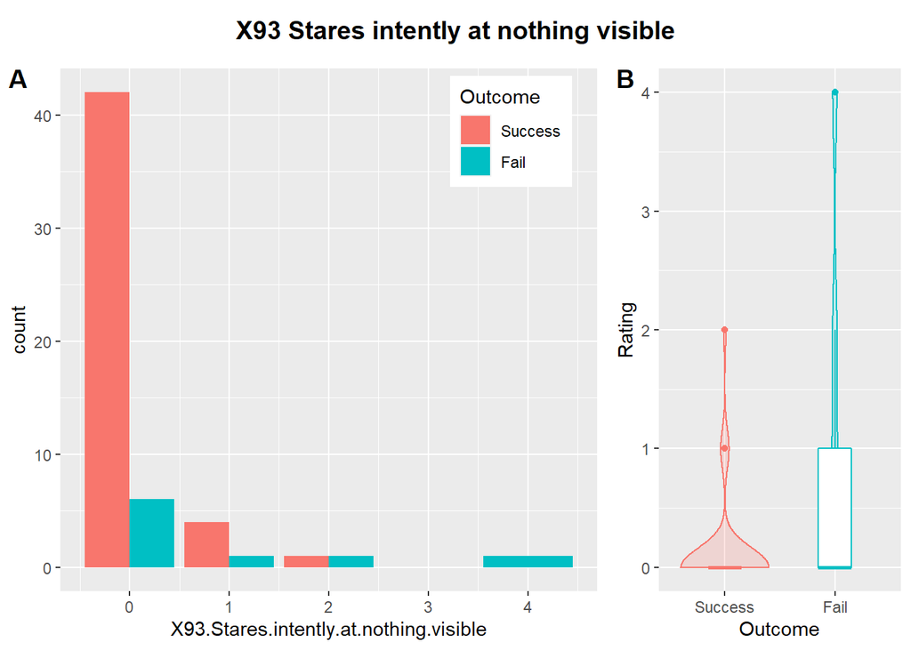

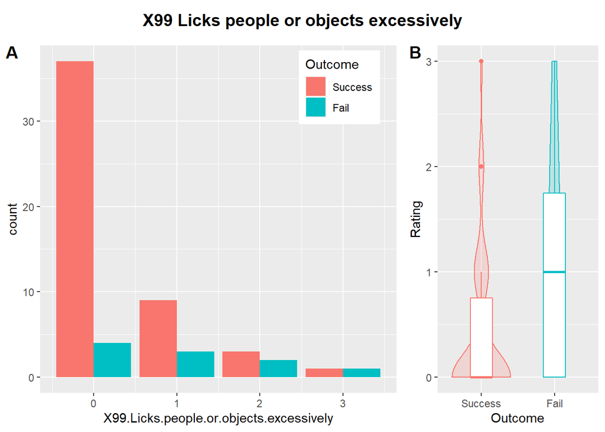

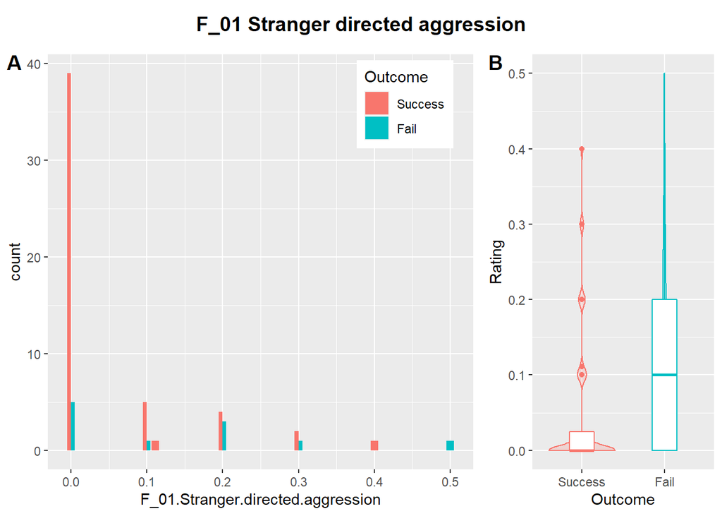

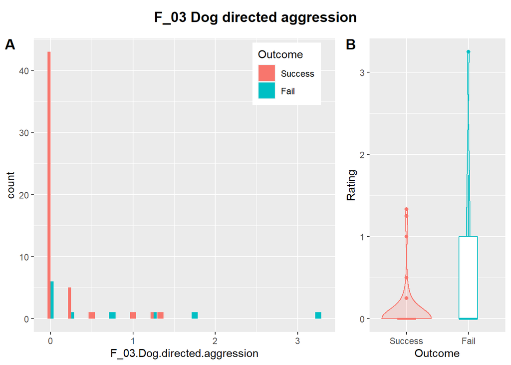

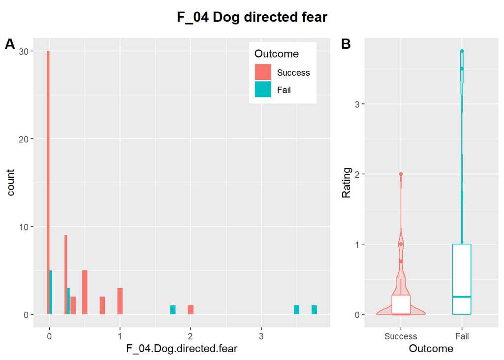

[3 more figures not shown]

```
## [1] "F_01.Stranger.directed.aggression"
## 0 0.5[1] 0.0 0.1 0.2 0.3 0.4 0.5
## [1] "F_03.Dog.directed.aggression"
## 0 3.25[1] 0.00 0.65 1.30 1.95 2.60 3.25
## [1] "F_04.Dog.directed.fear"
## 0 3.75[1] 0.00 0.75 1.50 2.25 3.00 3.75
## [1] "F_09.Nonsocial.fear"
## 0 1.6[1] 0.00 0.32 0.64 0.96 1.28 1.60
## [1] "F_10.Separation.related.problems"
## 0 1.5[1] 0.0 0.3 0.6 0.9 1.2 1.5
## [1] "F_12.Excitability"
## 0 3.833333[1] 0.0000000 0.7666667 1.5333333 2.3000000 3.0666667 3.8333333
```

```
## [[1]]
## [1] 0.0 0.1 0.2 0.3 0.4 0.5
##
## [[2]]
## [1] 0.00 0.65 1.30 1.95 2.60 3.25
##
## [[3]]
## [1] 0.00 0.75 1.50 2.25 3.00 3.75
##
## [[4]]
## [1] 0.00 0.32 0.64 0.96 1.28 1.60
##
## [[5]]
## [1] 0.0 0.3 0.6 0.9 1.2 1.5
##
## [[6]]
## [1] 0.0000000 0.7666667 1.5333333 2.3000000 3.0666667 3.8333333
```

## 1.6 Multicollinearity

Calculate Variance Inflation Factor (VIF) to avoid multicollinearity. The glm models were built on the Full and Reduced Feature Sets with p < 0.05 and excude any sample containing NAs. VIF larger than 5 or 10 is large and indicate a high level of multicollinearity.

```
## VIF reduced
```

```
##
## Call:
## glm(formula = Outcome ~ ., family = binomial(link = logit), data = data_reduced,
##     na.action = na.exclude)
##
## Deviance Residuals:
##        Min          1Q      Median          3Q         Max
## -1.618e-05  -1.195e-06  -2.110e-08  -2.110e-08   1.591e-05
##
## Coefficients:
##                                                                       Estimate
## (Intercept)                                                           -141.706
## X1.When.off.the.leash.returns.immediately.when.called                   -1.689
## X27.Toward.cats.squirrels.or.other.small.animals.entering.your.yard    -61.126
## X75.Chases.or.would.chase.birds.given.the.opportunity                   37.182
## X77.Escapes.or.would.escape.from.home.or.yard.given.the.chance          -6.360
## X82.Begs.persistently.for.food.when.people.are.eating                   35.044
## X85.Pulls.excessively.hard.when.on.the.leash                            12.514
## X90.Hyperactive.restless.has.trouble.settling.down                     -64.781
## X93.Stares.intently.at.nothing.visible                                  18.883
## X99.Licks.people.or.objects.excessively                                 37.483
## F_01.Stranger.directed.aggression                                      149.152
## F_03.Dog.directed.aggression                                           -47.896
## F_04.Dog.directed.fear                                                 -24.221
## F_09.Nonsocial.fear                                                     24.045
## F_10.Separation.related.problems                                        18.774
## F_12.Excitability                                                       10.204
##                                                                     Std. Error
## (Intercept)                                                         597454.430
## X1.When.off.the.leash.returns.immediately.when.called               207875.009
## X27.Toward.cats.squirrels.or.other.small.animals.entering.your.yard 240857.929
## X75.Chases.or.would.chase.birds.given.the.opportunity                51672.206
## X77.Escapes.or.would.escape.from.home.or.yard.given.the.chance      103283.458
## X82.Begs.persistently.for.food.when.people.are.eating                88588.247
## X85.Pulls.excessively.hard.when.on.the.leash                         74608.962
## X90.Hyperactive.restless.has.trouble.settling.down                  149377.250
## X93.Stares.intently.at.nothing.visible                              255815.718
## X99.Licks.people.or.objects.excessively                              95411.230
## F_01.Stranger.directed.aggression                                   995720.436
## F_03.Dog.directed.aggression                                        465337.628
```

[output cut: 32 more lines]

```
## F_01.Stranger.directed.aggression                                      1.000
## F_03.Dog.directed.aggression                                           1.000
## F_04.Dog.directed.fear                                                 1.000
## F_09.Nonsocial.fear                                                    1.000
## F_10.Separation.related.problems                                       1.000
## F_12.Excitability                                                      1.000
##
## (Dispersion parameter for binomial family taken to be 1)
##
##     Null deviance: 4.0191e+01  on 48  degrees of freedom
## Residual deviance: 2.0912e-09  on 33  degrees of freedom
##   (14 observations deleted due to missingness)
## AIC: 32
##
## Number of Fisher Scoring iterations: 25
```

```
##               X1.When.off.the.leash.returns.immediately.when.called
##                                                           73.654016
## X27.Toward.cats.squirrels.or.other.small.animals.entering.your.yard
##                                                           64.744266
##               X75.Chases.or.would.chase.birds.given.the.opportunity
##                                                           16.372672
##      X77.Escapes.or.would.escape.from.home.or.yard.given.the.chance
##                                                           45.346432
##               X82.Begs.persistently.for.food.when.people.are.eating
##                                                           28.491186
##                        X85.Pulls.excessively.hard.when.on.the.leash
##                                                           11.913370
##                  X90.Hyperactive.restless.has.trouble.settling.down
##                                                           34.870182
##                              X93.Stares.intently.at.nothing.visible
##                                                          246.380554
##                             X99.Licks.people.or.objects.excessively
##                                                           16.551780
##                                   F_01.Stranger.directed.aggression
##                                                           79.111346
##                                        F_03.Dog.directed.aggression
##                                                          130.352946
##                                              F_04.Dog.directed.fear
##                                                           11.539579
##                                                 F_09.Nonsocial.fear
##                                                            4.180477
##                                    F_10.Separation.related.problems
##                                                           52.155422
##                                                   F_12.Excitability
##                                                           25.070671
```

# 2 Multivariate Model

## 2.2 Recursive Feature Elimination (RFE) + Multivariate Logistic Regression (LR)

Features selection was performed using the Caret package Recursive Feature Elimination rfe function. Logistic Regression was used to model the dataset and Leave One Subject Out Cross Validation was employed to validate the results. [Caret RFE](https://search.r-project.org/CRAN/refmans/caret/html/rfe.html), [Caret RFE Control](https://search.r-project.org/CRAN/refmans/caret/html/rfeControl.html), [Examples using RFE with Recipes](http://topepo.github.io/caret/recursive-feature-elimination.html#rferecipes) [Example RFE + RF as predictor](https://towardsdatascience.com/effective-feature-selection-recursive-feature-elimination-using-r-148ff998e4f7), [RFE + ROC as metric](https://stackoverflow.com/questions/18242692/r-package-caret-rfe-function-how-to-customize-metric-to-use-auc).

Interpreting performance metrics:

```
## [1] "p<0.05 + reduced"
```

```
## [1] "Dimensions of original dataset:"
## [1] 63 16
```

```
##
## Recursive feature selection
##
## Outer resampling method: Leave-One-Out Cross-Validation
##
## Resampling performance over subset size:
##
##  Variables    ROC   Sens   Spec Selected
##          1 0.8059 0.9615 0.3636        *
##          2 0.6748 0.9231 0.3636
##          3 0.6346 0.9038 0.2727
##          4 0.5752 0.8846 0.1818
##          5 0.5262 0.8846 0.1818
##          6 0.5105 0.8462 0.1818
##          7 0.5105 0.8269 0.1818
##          8 0.5315 0.8269 0.1818
##          9 0.5437 0.8462 0.1818
##         10 0.5524 0.8462 0.1818
##         11 0.5752 0.8462 0.1818
##         12 0.5734 0.8462 0.1818
##
## The top 1 variables (out of 1):
##    PC01
##
##
## Call:
## glm(formula = Class ~ ., family = "binomial", data = tmp)
##
## Deviance Residuals:
##     Min       1Q   Median       3Q      Max
## -1.2977  -0.4700  -0.3413  -0.2674   2.2604
##
## Coefficients:
##             Estimate Std. Error z value Pr(>|z|)
## (Intercept)  -1.9366     0.4363  -4.439 9.05e-06 ***
## PC01         -0.6943     0.2280  -3.046  0.00232 **
## ---
## Signif. codes:  0 '***' 0.001 '**' 0.01 '*' 0.05 '.' 0.1 ' ' 1
##
## (Dispersion parameter for binomial family taken to be 1)
##
##     Null deviance: 58.352  on 62  degrees of freedom
## Residual deviance: 39.896  on 61  degrees of freedom
## AIC: 43.896
##
## Number of Fisher Scoring iterations: 5
```

```
##
## deviance difference:  18.45545
## df difference:  1
## level of significance:  1.739228e-05
## the model is a good fit:  TRUE
```

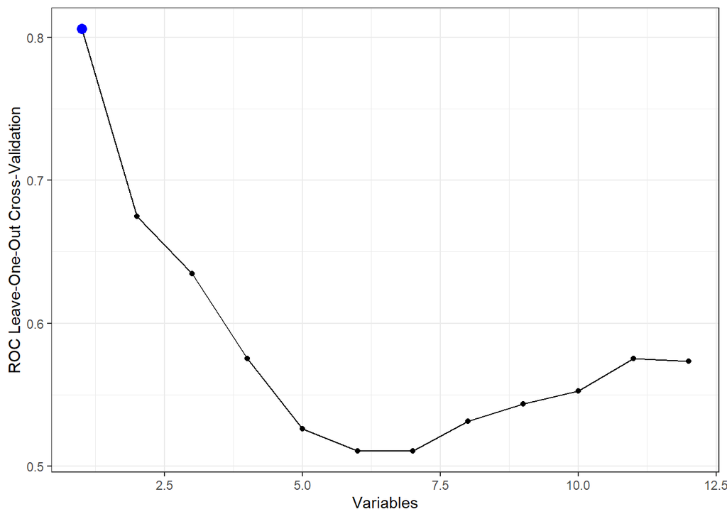

## 2.3 Interpretation

The best Logistic Regression model is used to investigate the effect of the principal components on the training outcome. The estimates were exponentiated to get the Odds Ratio (OR). The 95% Confident Interval (CI) of the ORs was also calculated. The OR for PC01 is 0.4994, this means that the probability of withdrawal decreases by (0.50-1) 50% for every unit increase of PC1. We are 95% confident that a unit increase in PC01 results in a 29 to 71% (0.29-1 = 0.71, 0.71-1 = 0.29) less odds of being withdrawn from training.

```
## [1] "Results from the model created with the reduced feature set"
```

```
##               Estimate Std. Error   z value     Pr(>|z|)        OR      2.5 %
## (Intercept) -1.9365519  0.4362771 -4.438811 9.045704e-06 0.1442003 0.05453555
## PC01        -0.6942693  0.2279632 -3.045533 2.322682e-03 0.4994392 0.29090682
##                97.5 %
## (Intercept) 0.3123707
## PC01        0.7218348
```

```
## [1] "Probability predicted by the LR using PRQ data vs true Outcome"
```

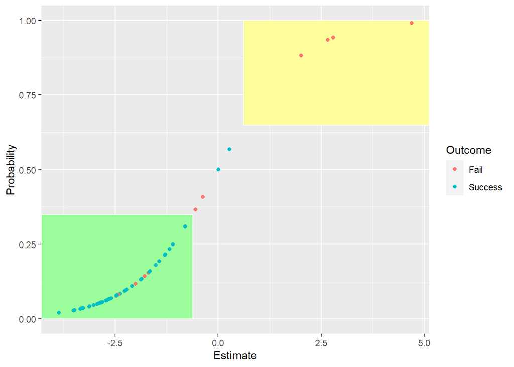

```
## [1] "Probability predicted by the LR using PRQ data vs true Status"
```

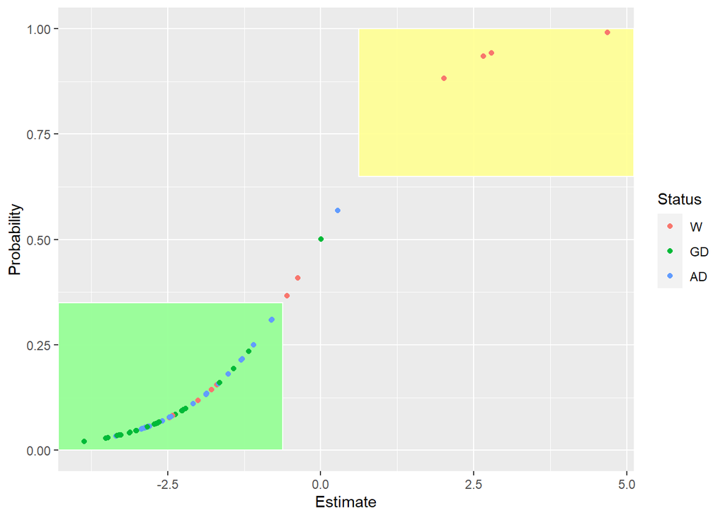

```
## Predicted probability < 0.35  -> Green flag
```

```
## [1] "Dogs flagged green are likely to SUCCEED, true outcome count and status proportion:"
```

```
##
##    Fail Success
##       5      50
```

```
##
##          W         GD         AD
## 0.09090909 0.45454545 0.45454545
```

```
## Predicted probability > 0.65 -> Yellow flag
```

[output not shown]

```
##
##    Fail Success
##       4       0
```

```
##
##  W GD AD
##  1  0  0
```

## 2.4 Feature Importance

### 2.4.1 Explained Variance

```
## PCA features kept in the final model after RFE:  PC01
```

```
## [1] "Explained Variance per Principal Component (Scree Plot)"
```

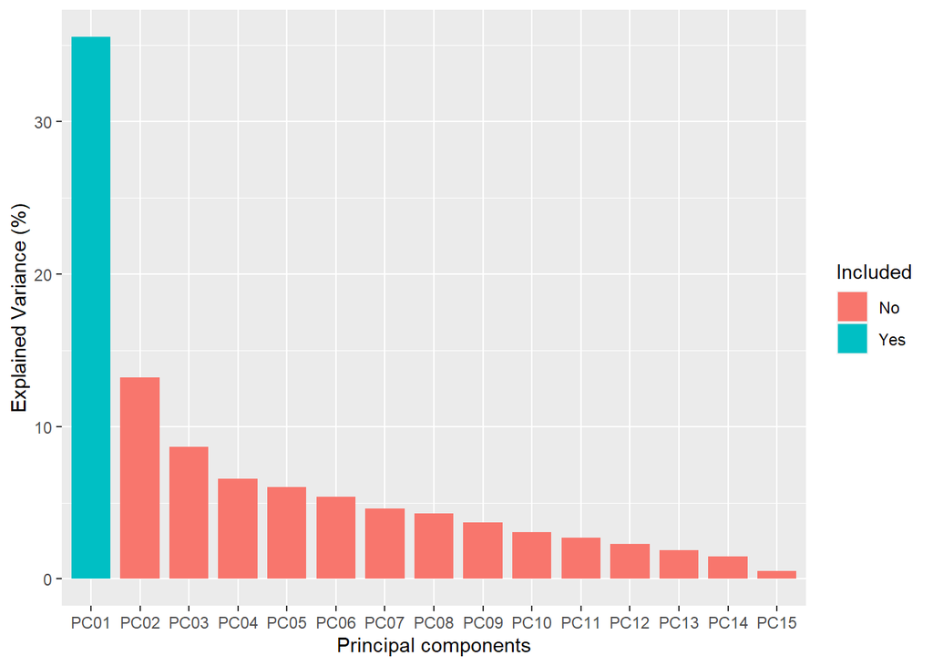

```
## [1] "Cumulative Explained Variance per Principal Component"
```

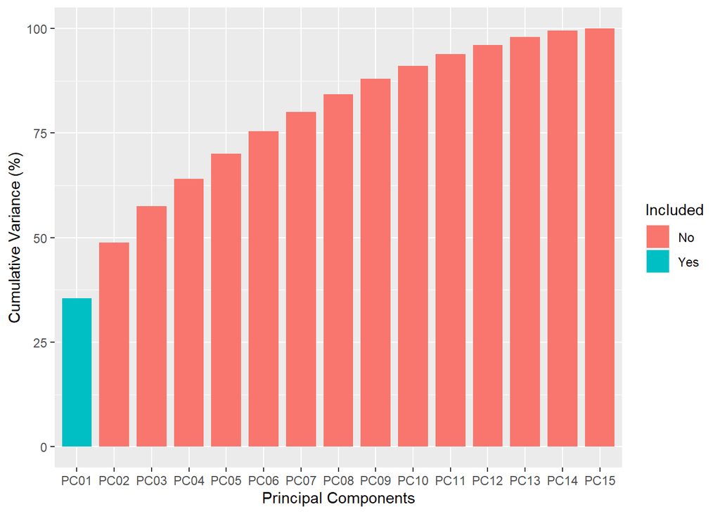

### 2.4.2 Coefficient Loadings

Analysis of the principal component loadings that were used in the best Multivariate Logistic Regression Model.

```
##                                                                  terms
## 1                                         F_03.Dog.directed.aggression
## 2                                               F_04.Dog.directed.fear
## 3                                                    F_12.Excitability
## 4                               X93.Stares.intently.at.nothing.visible
## 5                                     F_10.Separation.related.problems
## 6  X27.Toward.cats.squirrels.or.other.small.animals.entering.your.yard
## 7                                    F_01.Stranger.directed.aggression
## 8                                                  F_09.Nonsocial.fear
## 9                X1.When.off.the.leash.returns.immediately.when.called
## 10      X77.Escapes.or.would.escape.from.home.or.yard.given.the.chance
## 11                        X85.Pulls.excessively.hard.when.on.the.leash
## 12                  X90.Hyperactive.restless.has.trouble.settling.down
## 13                             X99.Licks.people.or.objects.excessively
## 14               X82.Begs.persistently.for.food.when.people.are.eating
```

[output cut: 17 more lines]

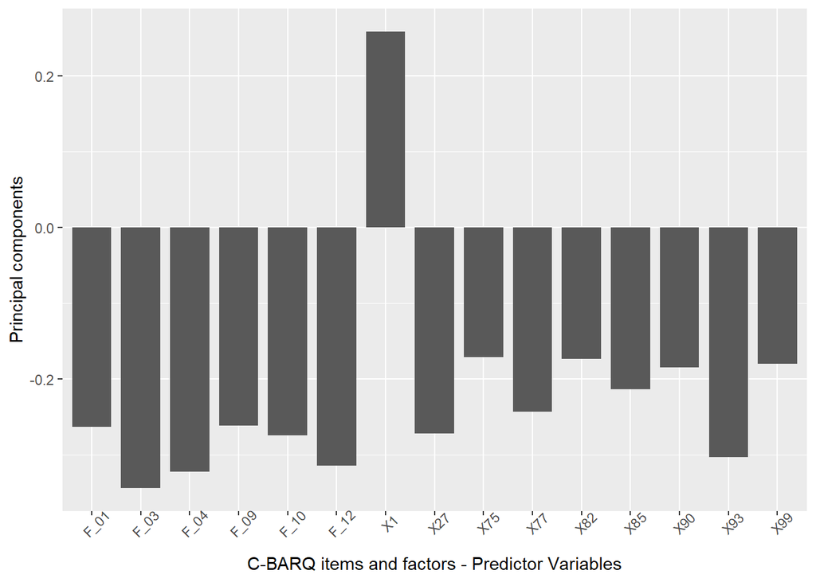

# 3 Conclusion

Duration of dog correctly classified as Fail and went on to Fail in days (Dog 16 = 100, Dog42 = 55, Dog51 = 113, Dog51 = 90), 30, 43, 20 days of training saved! 70 days for this assessment it could be done earlier too. Ideally assign a dog to a dog trainer from start to Week 3. They are them responsible for filling out the questionnaire.